# Ford GoBike System Data

## by Kola Ademola

## Investigation Overview

> For the presentaion I'll like to focus on how age affects the number of trips and even the number of people that subscribe to the Bike share program. I'll start by introducing the age variable and then show how it is distributed accross the dataset.

> After which I introduce how the diffrent age groups come out on:
> - The number of trips taken using a simple bar chart
> - The proportion of Subscribers to Customers using a simple pie chart
> - The number of subscribers compared to customers for each age group using a simple clustered bar chart for easy comparison.
> - The trend of trips taken over the month using a line plot.

## Dataset Overview

> This data set includes information about individual rides made in a bike-sharing system covering the greater San Francisco Bay area.

## Distribution of User Age

> The age of users takes on a range of **18 years as the youngest user** to the **oldest as 141 years old** and it's distribution is skewed to the right taking on a unimodal shape.  
> From the chart we can see how most users fall in between **20 - 50yrs**

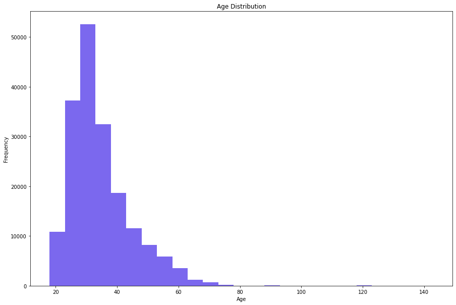

```python
viz1()
```

## Number of Trips by Age Group

> Plotting the count of trips for each age group shows clearly that most of the users are in the **18 - 30yrs** & **31 - 50yrs** bucket or in general like we saw in the age distribution **20 - 50yrs** is indeed correct..

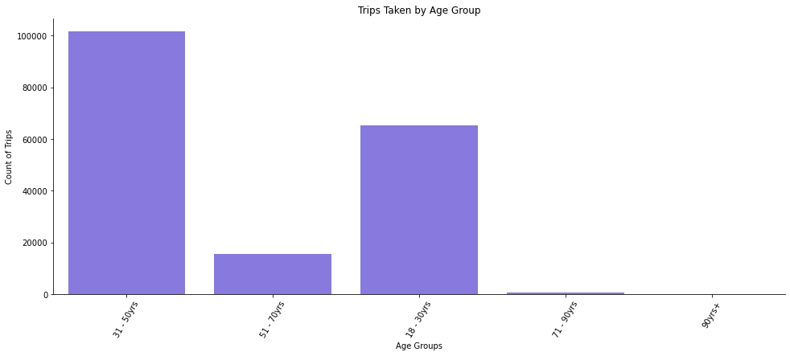

```python
viz2()
```

## Proportion of Subscribers to Customers

> Using a Pie Chart to show that **89%** of trips are taken by **Subscribers**

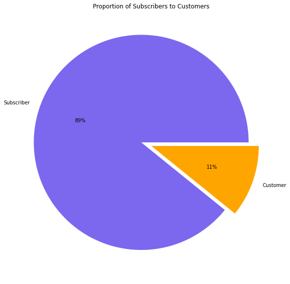

```python
viz3()
```

## Further look into the Proportion of Subscribers by Age Group

> I'll be using a Clustered bar chart to emphasize further on how most Subscribers that take the most trips are people between **18 - 50 years old**

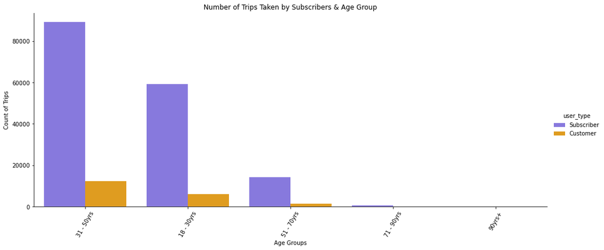

```python
viz4()
```

## Trend of Trips Over the weeks

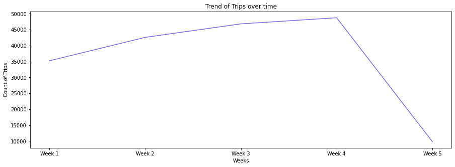

```python
viz5()
```

### CONCLUSIONS

#### Here are my Reccommendations;

- The marketing team should target their ads/marketing campaign towards younger audience.
- Ford GoBike can find a means to add incentive to being a **Subscriber**, to encourage customers to become **Subscribers**.
- Ford GoBike can also create an app that records subscribers total trip duration and rewards them with free trips to encourage more usage.